# OutFLANK: Finding FST outliers with an inferred neutral distribution

### Improving fit of OutFLANK

Hints:

- qthreshold is used to call outliers. The trim points must be located within any potential outliers. If qthreshold is set too high, OutFLANK will return an error.
- The algorithm may fail if RightTrimFraction is set too high
- Use the plotting function to check the fit of the inferred distribution to the right tail
- OutFLANK will not fit the left tail of the FST distribution well

Inputs:

- `FstDataFrame` is the input prepared above. (If your dataframe for OutFLANK is called “`myFs`”, then the argument would read `FstDataFrame = myFs`.)
- `LeftTrimFraction` and `RightTrimFraction` are arguments, each set to 5% by default, to tell OutFLANK how many of the lowest and highest FST values to remove before estimating the shape of the FST distribution through likelihood. (This removes the loci most affected by selection, and the likelihood procedure in OutFLANK accounts for the fact that data below and above these thresholds have been removed.) In some cases, when there are potentially a large number of loci affected by spatially heterogeneous selection, it can be worth trying a higher `RightTrimFraction`.
- `Hmin` is the threshold for expected heterozygosity. Loci with low He have distributions of FST very different from loci with higher He, and it is important to screen these out before proceeding. By default, OutFLANK removes from consideration all loci with expected heterozygosity less than 10%.
- `NumberOfSamples` is the number of populations sampled. This is the only other argument without a default, aside from the data frame.
- `qthreshold` sets the threshold for whether a locus is deemed an “outlier”, i.e. if the q-value for that locus is below this threshold. This is set to 5% by default (aiming at a 5% or lower false discovery rate.) These q-values are calculated based on the right-tail P-values for each locus.

Note that the OutFLANK maximum likelihood procedure calculates mean FST based on the trimmed data, but calculates the degrees of freedom based on the non-outliers. This means that none of the putative outliers can be inside of the trim points. So if you choose a `qthreshold` that is too large (such that outliers are within the trim points), the program will return an error.

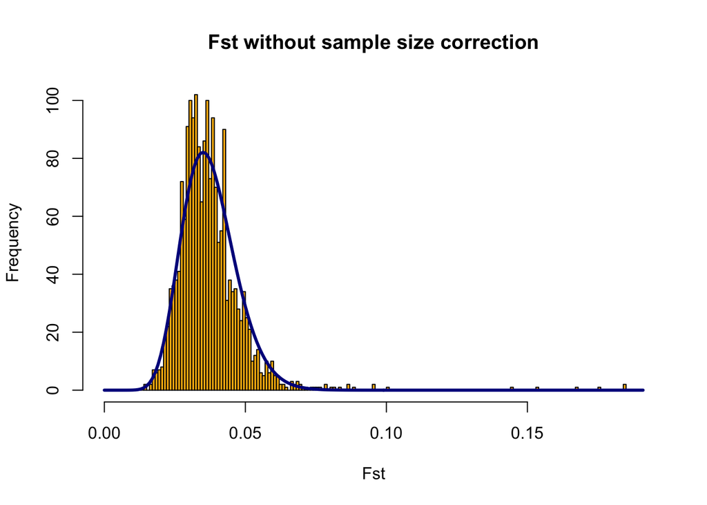

```r
  outlier = OutFLANK(FstDataFrame,NumberOfSamples = k,
                     RightTrimFraction = 0.06, LeftTrimFraction = 0.35,
                     qthreshold = 0.05, Hmin = 0.1)
    # increasing the Right Trim Fraction doesn't help, but increasing the left trim fraction enables a better fit

OutFLANKResultsPlotter(outlier, withOutliers = TRUE,
NoCorr = TRUE, Hmin = 0.1, binwidth = 0.001, Zoom =
FALSE, RightZoomFraction = 0.05, titletext = NULL)
```

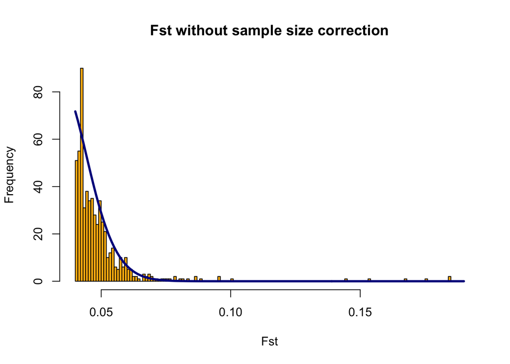

```r
    OutFLANKResultsPlotter(outlier, withOutliers = TRUE,
NoCorr = TRUE, Hmin = 0.1, binwidth = 0.001, Zoom =
TRUE, RightZoomFraction = 0.1, titletext = NULL)
```

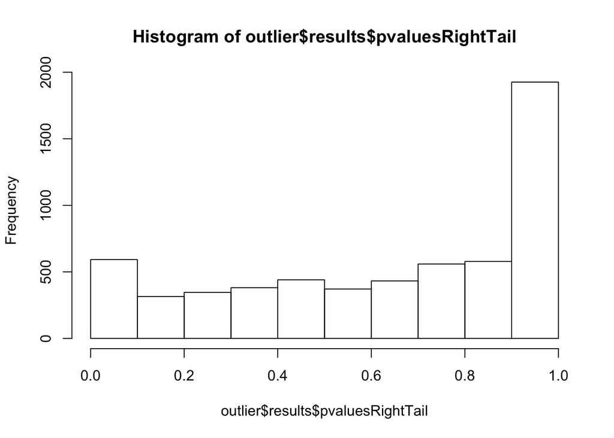

```r
  hist(outlier$results$pvaluesRightTail)
```

```r
    # note the excess of P-values near 1, indicating poor fit of the left tail
```

### Values output by OutFLANK

OutFLANK returns a data frame with the following values:

- `$FSTbar`: Mean FST of loci not flagged as outliers, using the sample-size correction (recommend reporting in publication)
- `$FSTNoCorrbar`: Mean FST of loci not flagged as outliers, without using the sample-size correction
- `$dfInferred`: Inferred df for the chi-square distribution from the OutFLANK procedure (recommend reporting in publication).
- `$numberLowFstOutliers`: Number of loci flagged as having a significantly low FST (not reliable)
- `$numberHighFstOutliers`: Number of loci flagged as having a significantly high FST.
- `$results`: a data frame with a row for each locus. This data frame includes all the original columns in the input data set, and six new ones:
- `$results$indexOrder`: the original row number of the locus in the input data set
- `$results$GoodH`: Boolean variable which is TRUE if the expected heterozygosity is greater than the `Hemin` set by the input to OutFLANK
- `$results$OutlierFlag`: TRUE if the method identifies the locus as an outlier, FALSE otherwise, based on the q-threshold
- `$results$q`: the q-value for the test of neutrality for the locus, based on the right-tailed P-value.
- `$results$pvalues`: the two-tailed P-value for the test of neutrality for the locus. Not reliable, because OutFLANK does not predict the left-tailed P-values well.
- `$results$pvaluesRightTail`: the one-sided (right tail) P-value for the locus

Let’s look at these values for our data

```r
  str(outlier)
```

```
## List of 6
##  $ FSTbar               : num 0.0174
##  $ FSTNoCorrbar         : num 0.0363
##  $ dfInferred           : num 31.2
##  $ numberLowFstOutliers : int 0
##  $ numberHighFstOutliers: int 132
##  $ results              :'data.frame':   5940 obs. of  15 variables:
##   ..$ LocusName       : Factor w/ 5879 levels "1_1006","1_10076",..: 1347 2528 4295 4703 1159 1433 1041 1101 243 1968 ...
##   ..$ He              : num [1:5940] 0.002 0.00698 0.01489 0.02566 0.00598 ...
##   ..$ FST             : num [1:5940] 0.01979 0.00108 0.01962 0.03821 0.00232 ...
##   ..$ T1              : num [1:5940] 1.98e-05 3.75e-06 1.46e-04 4.91e-04 6.94e-06 ...
##   ..$ T2              : num [1:5940] 0.001 0.00349 0.00745 0.01285 0.00299 ...
##   ..$ FSTNoCorr       : num [1:5940] 0.0386 0.0205 0.0383 0.0576 0.0218 ...
##   ..$ T1NoCorr        : num [1:5940] 3.86e-05 7.17e-05 2.85e-04 7.40e-04 6.51e-05 ...
##   ..$ T2NoCorr        : num [1:5940] 0.001 0.00349 0.00745 0.01285 0.00299 ...
##   ..$ meanAlleleFreq  : num [1:5940] 0.999 0.997 0.993 0.987 0.997 ...
##   ..$ indexOrder      : int [1:5940] 1 2 3 4 5 6 7 8 9 10 ...
##   ..$ GoodH           : Factor w/ 2 levels "goodH","lowH": 2 2 2 2 2 2 2 2 1 2 ...
##   ..$ qvalues         : num [1:5940] 1 1 1 0.419 1 ...
##   ..$ pvalues         : num [1:5940] 0.7463 0.0491 0.7697 0.0404 0.0753 ...
##   ..$ pvaluesRightTail: num [1:5940] 0.3731 0.9754 0.3849 0.0202 0.9623 ...
##   ..$ OutlierFlag     : logi [1:5940] FALSE FALSE FALSE FALSE FALSE FALSE ...
```

```r
  # Number of loci in the input SNP data:
  nrow(FstDataFrame)
```

```
## [1] 5940
```

```r
  # Number of loci in the OutFLANK output:
  nrow(outlier$results)
```

```
## [1] 5940
```

## Outliers

```r
sum(outlier$results$qvalues<0.01, na.rm=TRUE)
```

```
## [1] 95
```

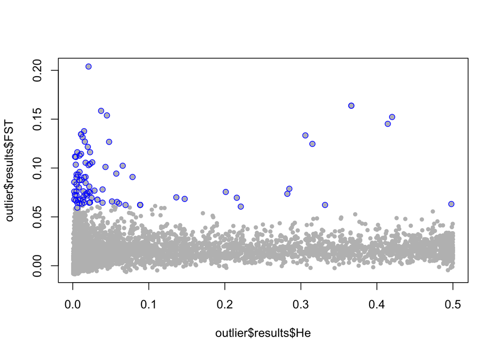

```r
plot(outlier$results$He, outlier$results$FST, pch=20, col="grey")
    points(outlier$results$He[outlier$results$qvalues<0.01], outlier$results$FST[outlier$results$qvalues<0.01], pch=21, col="blue")
```

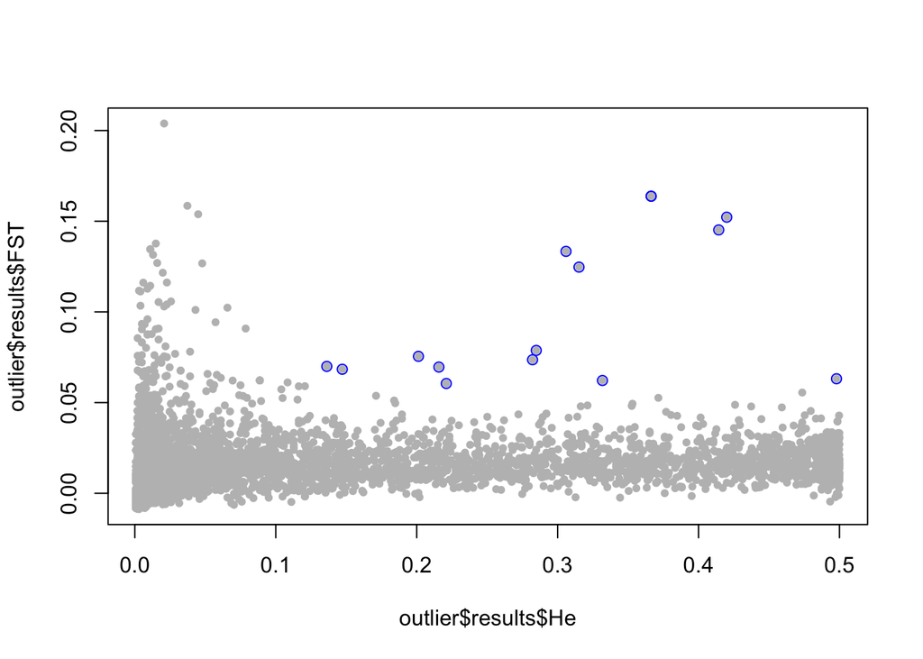

```r
### Note how OutFLANK identifies potential outliers at He < 0.1, even though
### these loci were excluded in the trimming algorithm

    # Create logical vector for top candidates
top_candidates <- outlier$results$qvalues<0.01 & outlier$results$He>0.1

plot(outlier$results$He, outlier$results$FST, pch=20, col="grey")
    points(outlier$results$He[top_candidates], outlier$results$FST[top_candidates], pch=21, col="blue")
```

```r
# list top candidates
    topcan <- outlier$results[top_candidates,]
    topcan[order(topcan$LocusName),]
```

```
##      LocusName        He        FST          T1         T2  FSTNoCorr
## 133    1_21786 0.3151680 0.12469568 0.019732082 0.15824191 0.14423176
## 3380   1_21818 0.3059355 0.13337439 0.020492557 0.15364686 0.15321252
## 5088   1_21929 0.3663555 0.16380182 0.030165908 0.18416100 0.18467192
## 312    1_21930 0.3663555 0.16380182 0.030165908 0.18416100 0.18467192
## 2958   1_22917 0.1472000 0.06838425 0.005045476 0.07378126 0.08601349
## 2670   1_27702 0.4978875 0.06315184 0.015757746 0.24952156 0.08126972
## 1193   2_52204 0.1361955 0.06997157 0.004776758 0.06826713 0.08673426
## 1268   3_81284 0.2209955 0.06053192 0.006704046 0.11075223 0.08095607
## 2665   3_81391 0.3318000 0.06218771 0.010341402 0.16629335 0.08335737
## 244    3_81633 0.2012355 0.07550753 0.007618202 0.10089328 0.09568694
## 5239   3_81730 0.4200000 0.15223112 0.032130827 0.21106609 0.17511068
## 5404   3_81785 0.4143020 0.14520750 0.030226205 0.20815871 0.16793686
## 314    3_81872 0.2848320 0.07876296 0.011249249 0.14282411 0.10015539
## 3087   3_81917 0.2822000 0.07361961 0.010415971 0.14148365 0.09521314
```

[output cut: 33 more lines]

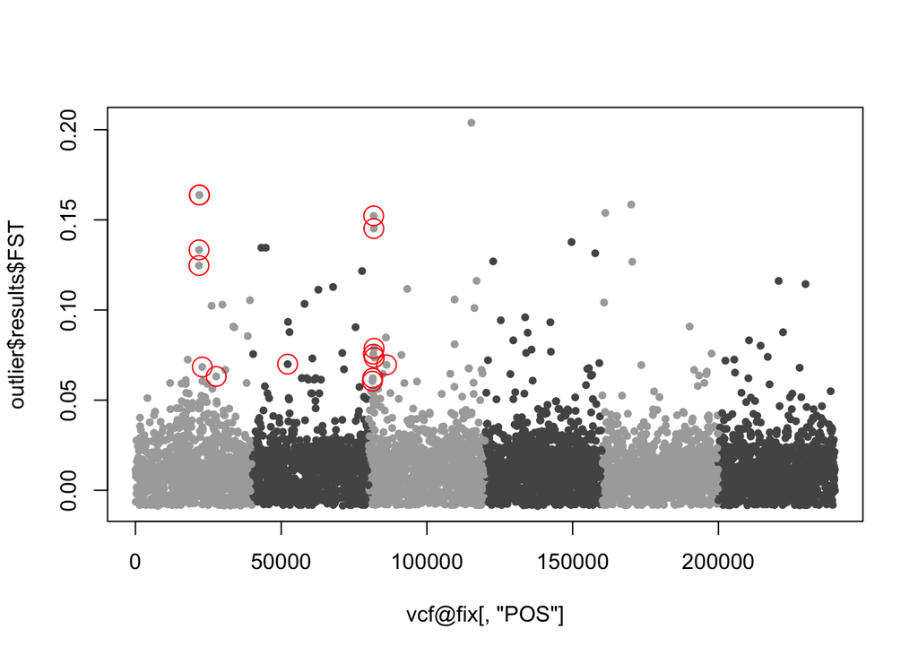

```r
plot(vcf@fix[,"POS"], outlier$results$FST,
     col=grey((as.numeric(vcf@fix[,"CHROM"])%%2+1)/3),
     pch=20
     )
  points(vcf@fix[top_candidates,"POS"], outlier$results$FST[top_candidates],
         pch=21, cex=2, col=2)
```

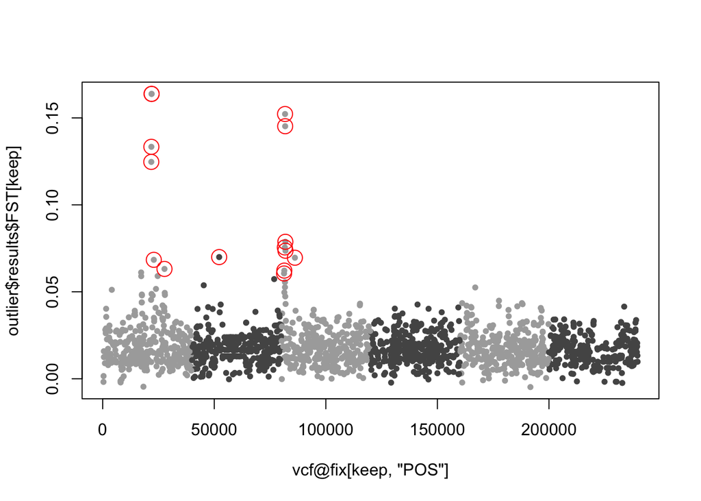

```r
  # clean up by removing low freq variants
  keep <- outlier$results$He>0.1 & !is.na(outlier$results$He)
plot(vcf@fix[keep,"POS"], outlier$results$FST[keep],
     col=grey((as.numeric(vcf@fix[keep,"CHROM"])%%2+1)/3),
     pch=20
     )
  points(vcf@fix[top_candidates,"POS"], outlier$results$FST[top_candidates],
         pch=21, cex=2, col=2)
```

### Challenge questions:

Can you adjust the RightTrimFraction and the qthreshold in the OutFLANK procedure to improve the results? What happens if you increase the RightTrimFraction? Just the qthreshold? How high can you increase these values until the algorithm fails?